# Lab assignment 3

```r
library(tidyverse)
library(nycflights13)
```

## Are weather and delays correlated?

Consider the `nycflights13` package, and the join between the average daily delay and the weather on that day. The following code block makes available this information.

```r
# this block of code is the solution to last week's exercise
average_delay <- flights %>%
  drop_na(dep_delay) %>%
  group_by(origin, year, month, day) %>%
  summarise(dep_delay = mean(dep_delay))
weather_delay <- weather %>%
  drop_na(wind_speed, temp, precip) %>%
  group_by(origin, year, month, day) %>%
  summarise(
    wind_speed = mean(wind_speed),
    temp = mean(temp),
    precip = mean(precip)
  ) %>%
  inner_join(average_delay, by=c("origin", "year", "month", "day"))
weather_delay
```

```
## # A tibble: 1,092 × 8
## # Groups:   origin, year, month [36]
##    origin  year month   day wind_speed  temp precip dep_delay
##    <chr>  <int> <int> <int>      <dbl> <dbl>  <dbl>     <dbl>
##  1 EWR     2013     1     1      13.2   36.8      0     17.5
##  2 EWR     2013     1     2      10.9   28.7      0     25.3
##  3 EWR     2013     1     3       8.58  29.6      0      8.45
##  4 EWR     2013     1     4      14.0   34.3      0     12.1
##  5 EWR     2013     1     5       9.40  36.6      0      5.70
##  6 EWR     2013     1     6       9.11  39.9      0     12.4
##  7 EWR     2013     1     7       7.34  40.3      0      9.78
##  8 EWR     2013     1     8       7.19  38.6      0      3.81
##  9 EWR     2013     1     9       5.99  42.1      0      3.13
## 10 EWR     2013     1    10       8.92  43.6      0      5.58
## # … with 1,082 more rows
```

Plot the data in the `weather_delay` dataset using several combinations of `geom_point` and `geom_smooth` as detailed in the following code blocks. Remember that you can adjust the appearance of the plots in the rendered notebook using the chunk options `fig.width` and `fig.height`

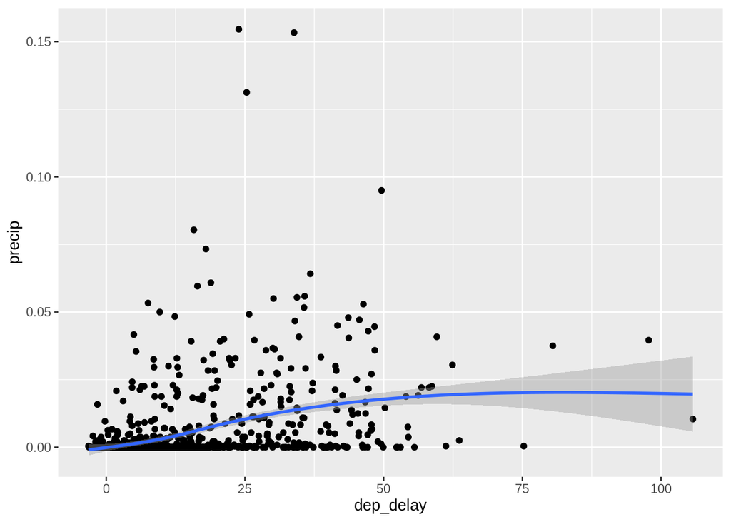

```r
# Plot the delay against the average precipitation of the day
ggplot(data = weather_delay, mapping = aes(x = dep_delay, y = precip)) + geom_point() + geom_smooth()
```

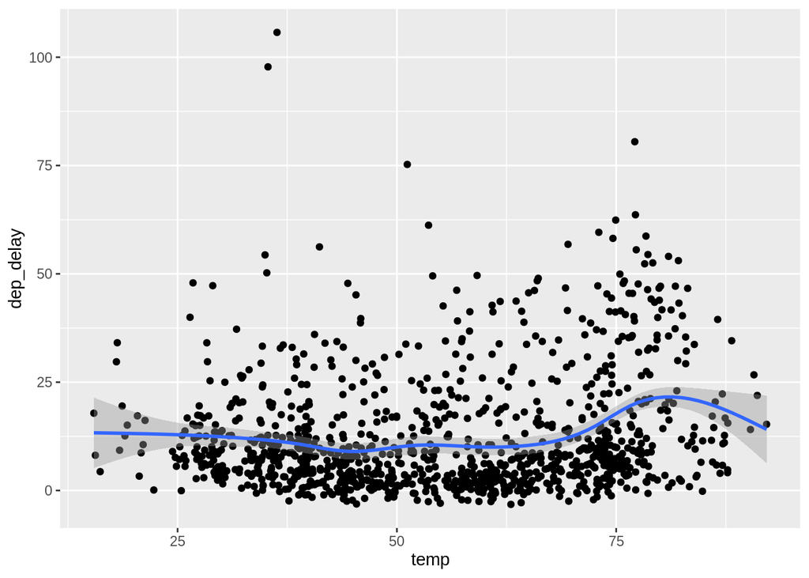

```r
# Plot the delay against the temperature of the day
ggplot(data = weather_delay, mapping = aes(y = dep_delay, x = temp)) + geom_point() + geom_smooth()
```

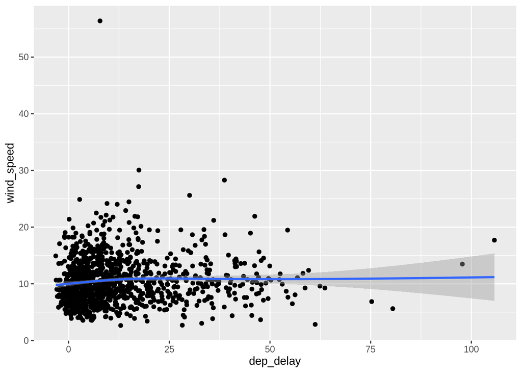

```r
# Plot the delay against the wind speed of the day
ggplot(data = weather_delay, mapping = aes(x = dep_delay, y = wind_speed)) + geom_point() + geom_smooth()
```

Can you spot any correlations?

Now try to represent several variables in the dataset at once in the same plot. In particular, represent in a single scatterplot the `wind_speed`, the `temp`, the `precip` and the `dep_delay`. Remember that you can use several different aesthetic channels at the same time, one for each different variable. Examples of the aesthetics you might want to use are `x`, `y`, `size`, `color`, `shape`.

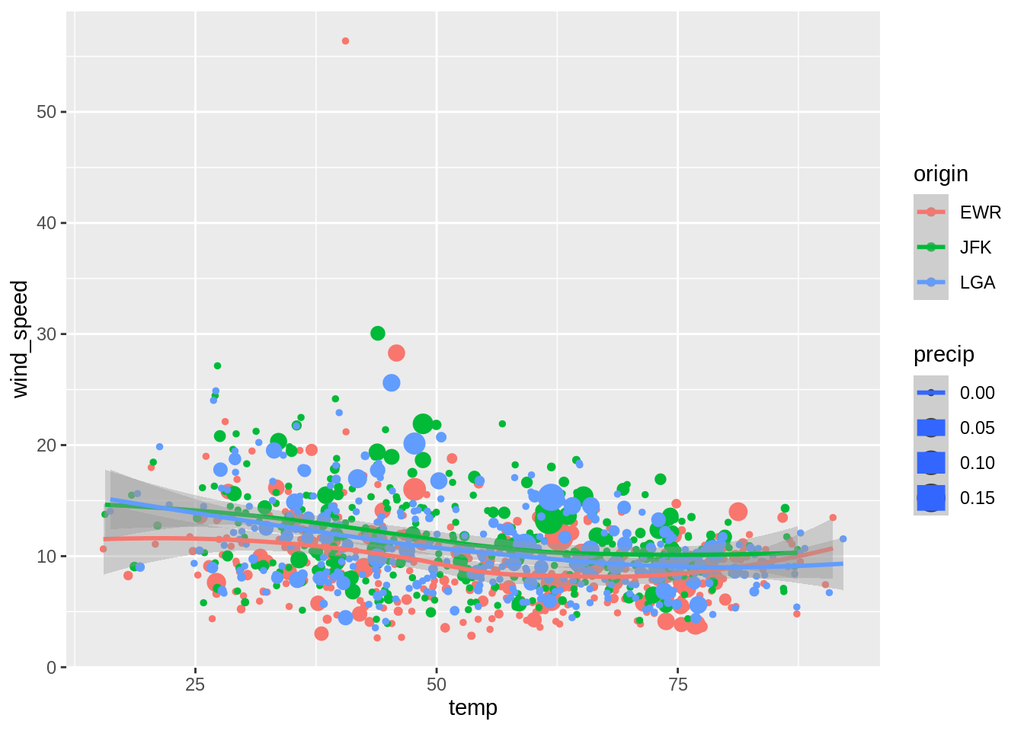

```r
# Your solution here
ggplot(data = weather_delay, mapping = aes(y = wind_speed,x = temp,size = precip,color = origin)) + geom_point() + geom_smooth()
```

## Is there a dependency on the time of the year?

Consider the `flights` dataset.

- Plot the departure delay against the month. Can you discern any pattern from the plot?

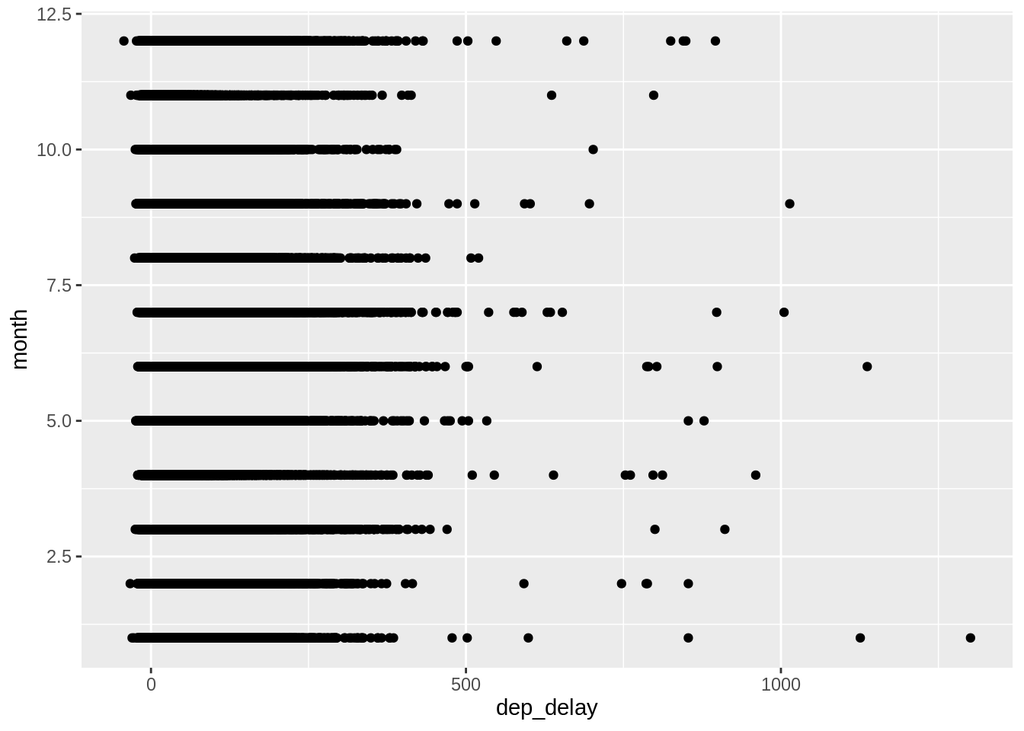

```r
# your solution here
ggplot(data = flights, mapping = aes(x = dep_delay, y = month)) + geom_point()
```

- Try to plot the *average* delay against the month. What can you conclude? *Hint*: you can either compute the average delay in the preprocessing pipeline using `group_by` and  
  `summarise` or you can use the `stat = "summary"` argument to `geom_point` or `geom_bar`.

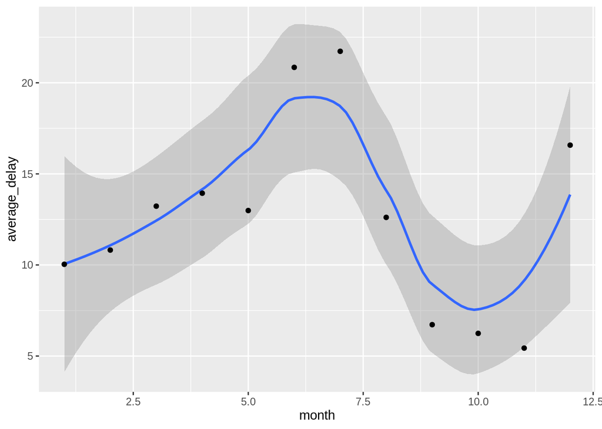

```r
# your solution
average_delay <- flights%>% group_by(month)%>%summarise(average_delay = mean(dep_delay, na.rm = T))%>%
ggplot(mapping = aes(y = average_delay, x = month)) + geom_smooth(na.rm = T) + geom_point(na.rm = T)

average_delay
```

- What about plotting the delay against the day of the year (thus ranging from 1 to 365)? You can use the `days` dataframe provided below to get the day of the year. Remember that there are several flights per day, so you will have to take the average delay for each day of the year.

```r
days <- flights %>%
  distinct(month, day)%>%
  arrange(month, day) %>%
  mutate(day_of_year = row_number())
```

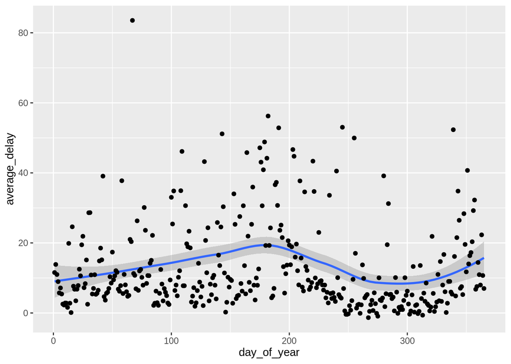

```r
# your solution here
days <- flights %>%
  distinct(month, day)%>%
  arrange(month, day) %>%
  mutate(day_of_year = row_number())

average_delay <- inner_join(flights, days)%>% group_by(month, day, day_of_year)%>% summarise(average_delay =mean(dep_delay, na.rm = T))%>%
  ggplot(mapping = aes(y = average_delay, x = day_of_year))+geom_smooth(na.rm = T)+geom_point(na.rm = T)
average_delay
```